# INFO521 - Intro to ML - Project Final Report - Analysis and Prediction of Earthquake Data

Tharun Murugesh R & Shanmuganathan C

06/12/2022

# Introduction

## Research Problem

### Earthquakes have been the cause of mass destruction to life and property every single year across the world.

### The seismic activity due to an earthquake causes other natural disasters like floods, landslides, tsunamis, avalanches etc.

### Despite the advancement of technology that allow structures to withstand an earthquake, it still remains a feared natural disaster among all.

### An earthquake is generally characterized by the depth and the magnitude with the depth being significant as the depth of the earthquake gives us insights into the information on the Earth’s structure, more specifically the mechanics and characteristics of the deformation of the Earth’s surface and the tectonic setting where the earthquake is occurring by plotting the location and the depth.

### The magnitude or the size of the earthquake is measured by a seismograph. Besides giving an insight into the intensity of the earthquake, it may be able to explain the roughness of the fault surfaces.

## Related Works (Literature Survey)

### In [1], Asim, Basit et al. used eight seismic indicators in the earthquake catalog of the Hindukush region to predict future earthquakes in the region.The authors used four machine learning techniques including Pattern Recognition Neural Network, Recurrent Neural Network, Random Forest and Linear Programming Boost Ensemble classifier. They were separately applied to model relationships between the calculated seismic parameters and future earthquake occurrences.

### In [2], Tehseen et al. conducted a meta-analysis of different prediction methods, including Rule-based systems, Fuzzy Expert Systems, Neuro-Fuzzy Systems and other Machine Learning algorithms, used over different geographical regions. Multiple publications using the above methods with various datasets and parameters were analyzed. The accuracies that were achieved in each of those publication were compared.

### In [3], Geologists and Seismologists have conducted analysis on earthquakes that have taken place in countries like Turkey, Japan etc., with Japan being an earthquake and tsunami prone nation, a lot of insights can be drawn from its analysis.

## Knowledge Gap

### Our project will be limited to the algorithms that we have learnt during this course and will also be considering tectonic plates as an important geographical attribute, which the previously mentioned projects have not.

### Since this project deals with earthquakes and tectonic plates, it is important to explain what they actually are so that people from other backgrounds will get to understand more about these geographical phenomena.

### Tectonic plates are massive irregularly shaped slabs of solid rock which slide past each other and at times, gets stuck which leads to large amounts of built-up energy, eventually being released, causing an earthquake.

## Purpose of Study and Objectives

### The purpose of our study is to establish a relationship between earthquakes and tectonic plates, taking into account the magnitude and focal depth and see which tectonic plates have incurred most impact.

### Hence, in order to be better informed on past earthquakes , as well as potential future occurrences, we aim to create a set of informational material easy for people to understand the impact of earthquakes all around the world.

### We also aim to create few models that are able to predict the scale and depth of an earthquake and try to forecast disaster prone areas with respect to past occurrences.

### The above mentioned tasks are to be fulfilled with the help of sufficient EDA, visualizations, regression, classification and time-series forecasting.

# Methods and Materials

## Data Materials

### The subset (without NA values ; ~825 records) will be used for visualizing focal depth and for performing other tasks in this project.

## Subset - Data Summary

### It can be observed from the summary that most earthquakes were strong i.e. with magnitude between 6 and 7 and were of shallow depth i.e. focal depth between 0 and 70 km.

## Dataset Description

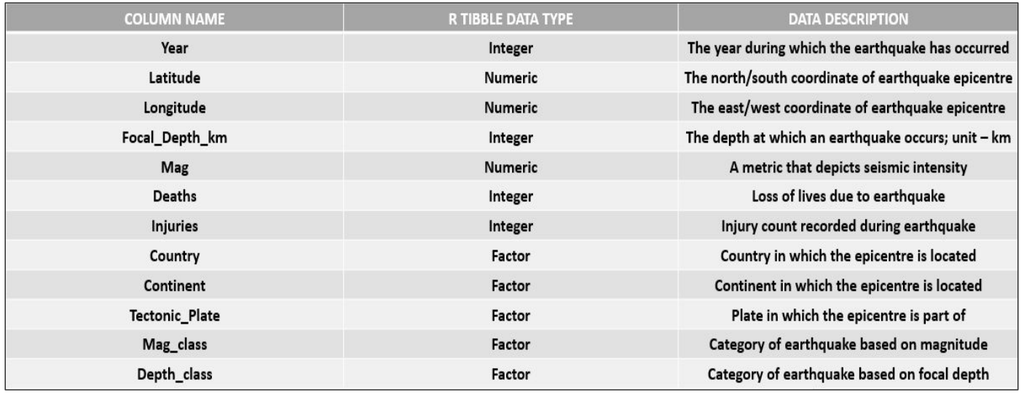

### Here we have provided a brief description about the columns we will be using for our project. The data as such is a mix of integer, numeric and factor data.

### The most important geographic parameters from the dataset are focal depth (units in kilometer) and magnitude of an earthquake and the tectonic plate. These parameters will be playing a crucial role as most of our analysis is regarding these variables.

### We have other secondary parameters such as country, continent, epicenter coordinates, etc.

## Methods

### The work flow of our project is as follows. These will be explained in detail with the below chunks of code.

### Required Package Installation

### Data Manipulation

### Visualization

### Regression

### Classification

### Risk Raster Map (Time Series Forecasting)

## Required Package Installation

### A number of packages were required for carrying out our analysis. The packages installed were used for a number of functions.

### Its uses include data manipulation, correlation, visualization, regression, classification and time series forecasting.

### List of packages used -

#### dplyr

#### ggcorrplot, corrplot

#### ggplot2, maps, grid, RColorBrewer

#### caret, tidyverse, stats

#### randomForest, gbm, rpart, rpart.plot, rattle

#### forecast, ggshadow

## Data Manipulation

### We have loaded the required data set using the read.csv() function.

### Next, we removed the unwanted columns from the dataset and stored the resulting data set under new variables.

### We have used loops to create new columns Mag_class & Depth_class for categorizing the earthquake occurrences based on the scale and focal depth of the earthquake.

### We have converted the character columns into factor data type.

### We also created a subset from the main dataset by removing the NA values for the columns which were required for performing our tasks.

### The above steps were were executed in the code chunk given below -

```r
#Reading the main dataset
data <- read.csv("C:/Users/Muthug/Desktop/INFO521 Intro to ML/fpquake.csv")

#Removing unnecessary columns from main dataset
df <- data[-c(2:8,14,16,18,20,22,24,26,28,30,32,34,36,38)]

#Categorizing Earthquake Magnitude on the basis of Richter Scale
df$Mag_class <- ifelse(df$Mag>=4&df$Mag<=4.9,"Light",NA)
df$Mag_class <- ifelse(df$Mag>=5&df$Mag<=5.9,"Moderate",df$Mag_class)
df$Mag_class <- ifelse(df$Mag>=6&df$Mag<=6.9,"Strong",df$Mag_class)
df$Mag_class <- ifelse(df$Mag>=7&df$Mag<=7.9,"Major",df$Mag_class)
df$Mag_class <- ifelse(df$Mag>=8&df$Mag<=9.9,"Great",df$Mag_class)

#Categorizing Earthquakes on the basis of Focal Depth
df$Depth_class <- ifelse(df$Focal_Depth_km>=0&df$Focal_Depth_km<=70,"Shallow",NA)
df$Depth_class <- ifelse(df$Focal_Depth_km>=71&df$Focal_Depth_km<=300,"Intermediate",df$Depth_class)
df$Depth_class <- ifelse(df$Focal_Depth_km>=301&df$Focal_Depth_km<=700,"Deep",df$Depth_class)

#Converting columns into factor type of data
df$Country <- as.factor(df$Country)
df$Continent <- as.factor(df$Continent)
df$Tectonic_Plate <- as.factor(df$Tectonic_Plate)
df$Mag_class <- as.factor(df$Mag_class)
df$Depth_class <- as.factor(df$Depth_class)

#Removing unwanted columns from main dataset
df <- df[-c(8,10:18)]
summary(df)
```

```
##       Year      Location_Name         Latitude        Longitude
##  Min.   :1800   Length:3968        Min.   :-62.88   Min.   :-179.98
##  1st Qu.:1930   Class :character   1st Qu.:  0.20   1st Qu.: -36.91
##  Median :1977   Mode  :character   Median : 26.91   Median :  63.86
##  Mean   :1963                      Mean   : 19.12   Mean   :  43.87
##  3rd Qu.:2004                      3rd Qu.: 38.17   3rd Qu.: 121.33
##  Max.   :2022                      Max.   : 73.12   Max.   : 180.00
##
##  Focal_Depth_km        Mag            Deaths          Injuries
##  Min.   :  0.00   Min.   :4.000   Min.   :     1   Min.   :     1.0
##  1st Qu.: 11.00   1st Qu.:5.700   1st Qu.:     2   1st Qu.:    10.0
##  Median : 25.00   Median :6.500   Median :    11   Median :    40.5
##  Mean   : 41.15   Mean   :6.434   Mean   :  1595   Mean   :  2210.8
##  3rd Qu.: 38.00   3rd Qu.:7.300   3rd Qu.:    96   3rd Qu.:   200.0
##  Max.   :675.00   Max.   :9.500   Max.   :316000   Max.   :799000.0
##  NA's   :803                      NA's   :2361     NA's   :2668
##           Country             Continent    Tectonic_Plate    Mag_class
##  China        : 431   Africa       : 129   EU     :1182   Great   : 181
##  Indonesia    : 317   Antarctica   :   1   AU     : 480   Light   : 312
##  Japan        : 251   Asia         :2110   AR     : 325   Major   :1212
##  Iran         : 226   Europe       : 413   AM     : 313   Moderate: 983
##  United States: 211   North America: 529   AN     : 224   Strong  :1280
##  Turkey       : 183   Oceania      : 361   (Other):1096
##  (Other)      :2349   South America: 425   NA's   : 348
##        Depth_class
##  Deep        :  45
##  Intermediate: 287
##  Shallow     :2833
##  NA's        : 803
##
##
##
```

```r
#Reading the new subset
data_2 <- read.csv("C:/Users/Muthug/Desktop/INFO521 Intro to ML/fpquake2.csv")

#Removing unnecessary columns from subset
df_2 <- data_2[-c(2:8,14,16,18,20,22,24,26,28,30,32,34,36,38)]

#Categorizing Earthquake Magnitude on the basis of Richter Scale
df_2$Mag_class <- ifelse(df_2$Mag>=4&df_2$Mag<=4.9,"Light",NA)
df_2$Mag_class <- ifelse(df_2$Mag>=5&df_2$Mag<=5.9,"Moderate",df_2$Mag_class)
df_2$Mag_class <- ifelse(df_2$Mag>=6&df_2$Mag<=6.9,"Strong",df_2$Mag_class)
df_2$Mag_class <- ifelse(df_2$Mag>=7&df_2$Mag<=7.9,"Major",df_2$Mag_class)
df_2$Mag_class <- ifelse(df_2$Mag>=8&df_2$Mag<=9.9,"Great",df_2$Mag_class)

#Categorizing Earthquakes on the basis of Focal Depth
df_2$Depth_class <- ifelse(df_2$Focal_Depth_km>=0&df_2$Focal_Depth_km<=70,"Shallow",NA)
df_2$Depth_class <- ifelse(df_2$Focal_Depth_km>=71&df_2$Focal_Depth_km<=300,"Intermediate",df_2$Depth_class)
df_2$Depth_class <- ifelse(df_2$Focal_Depth_km>=301&df_2$Focal_Depth_km<=700,"Deep",df_2$Depth_class)

#Converting columns into factor type of data
df_2$Country <- as.factor(df_2$Country)
df_2$Continent <- as.factor(df_2$Continent)
df_2$Tectonic_Plate <- as.factor(df_2$Tectonic_Plate)
df_2$Mag_class <- as.factor(df_2$Mag_class)
df_2$Depth_class <- as.factor(df_2$Depth_class)

#Removing unwanted columns from subset
df_2 <- df_2[-c(8,10:18)]
summary(df_2)
```

```
##       Year      Location_Name         Latitude         Longitude
##  Min.   :1880   Length:821         Min.   :-43.583   Min.   :-178.25
##  1st Qu.:1981   Class :character   1st Qu.:  5.568   1st Qu.:  13.64
##  Median :1999   Mode  :character   Median : 27.584   Median :  57.90
##  Mean   :1993                      Mean   : 20.576   Mean   :  45.51
##  3rd Qu.:2011                      3rd Qu.: 36.524   3rd Qu.: 105.54
##  Max.   :2022                      Max.   : 52.629   Max.   : 176.76
##
##  Focal_Depth_km        Mag           Deaths          Injuries
##  Min.   :  0.00   Min.   :4.00   Min.   :     1   Min.   :     1
##  1st Qu.: 10.00   1st Qu.:5.60   1st Qu.:     2   1st Qu.:    20
##  Median : 19.00   Median :6.30   Median :     7   Median :   100
##  Mean   : 28.86   Mean   :6.29   Mean   :  1655   Mean   :  3386
##  3rd Qu.: 33.00   3rd Qu.:6.90   3rd Qu.:    47   3rd Qu.:   400
##  Max.   :267.00   Max.   :9.50   Max.   :316000   Max.   :799000
##
##       Country            Continent   Tectonic_Plate    Mag_class
##  China    : 94   Africa       : 46   EU     :301    Great   : 30
##  Indonesia: 89   Asia         :514   AR     :103    Light   : 61
##  Iran     : 81   Europe       : 81   AU     : 74    Major   :174
##  Turkey   : 44   North America: 75   AM     : 55    Moderate:235
##  Japan    : 39   Oceania      : 18   AP     : 37    Strong  :321
##  Peru     : 34   South America: 87   (Other):232
##  (Other)  :440                       NA's   : 19
##        Depth_class
##  Intermediate: 54
##  Shallow     :767
##
##
##
##
##
```

## Visualization

### Firstly, we created tables for some columns for categorizing the earthquakes on the basis of country, continent, tectonic plate, depth and magnitude classes.

### Next, we used bar plots to highlight the number of occurrences in each continent, tectonic plate, magnitude and depth classes.

### We also made use of box plots to understand the variations of magnitude with respect to each continent, magnitude and depth classes.

### Further, we implemented line plots for identifying the number of earthquakes in each continent and also its magnitude over the years.

### We used world maps to visualise the epicenters of earthquakes with respect to magnitude and focal depth.

### Additionally, we used a correlogram to establish a relationship among the variables used.

```r
library(ggplot2)

#Creating tables
df_Cont <- table(df$Continent)
df_Nation <- table(df$Country)
df_Plate <- table(df$Tectonic_Plate)
df_Magclass <- table(df$Mag_class)
df_Depthclass <- table(df$Depth_class)

#Barplots for the tables created above
bp_1 <- ggplot(df,aes(Continent))+geom_bar()+xlab("Continent")+ylab("Number of Earthquakes")+ggtitle("Number of Earthquake Occurences in each continent")

bp_2 <- ggplot(df,aes(Tectonic_Plate))+geom_bar()+xlab("Tectonic Plate")+ylab("Number of Earthquakes")+ggtitle("Number of Earthquake Occurences in each tectonic plate")+
  theme(axis.text.x = element_text(angle = 90))

bp_3 <- ggplot(df,aes(Mag_class))+geom_bar()+xlab("Magnitude Class based on Richter scale")+ylab("Number of Earthquakes")+ggtitle("Number of Earthquake Occurences with respect to Magnitude class")

bp_4 <- ggplot(df_2,aes(Depth_class))+geom_bar()+xlab("Depth Class based on Focal Depth of Earthquake")+ylab("Number of Earthquakes")+ggtitle("Number of Earthquake Occurences with respect to Depth class")

library(dplyr)
#To obtain yearly count of earthquake occurences

yearly_counts <- df %>%
  count(Year,Continent)

#Line plots

lp_1 <- ggplot(data=yearly_counts,aes(x=Year,y=n,color=Continent))+
  ylab('Frequency')+
  geom_line()+
  facet_wrap(facets = vars(Continent))+
  ggtitle("Number of Earthquake Occurences in each continent over the years")

lp_2 <- ggplot(data=df,aes(x=Year,y=Mag))+
  geom_line(aes(color=Continent),size=1)+
  facet_wrap(facets = vars(Continent))+
  ggtitle("Magnitude of earthquakes in each continent over the years")

#Box plots

box_1 <- ggplot(df,aes(x=Continent,y=Mag))+
  geom_boxplot(aes(color=Continent))+
  ylab("Magnitude")+
  ggtitle("Trends of Magnitude in each continent")

box_2 <- ggplot(df,aes(x=Mag_class,y=Mag))+
  geom_boxplot(aes(color=Mag_class))+ylab("Magnitude")+
  xlab('Magnitude Class')+guides(color=guide_legend(title="Magnitude Class"))+
  ggtitle("Trends of Magnitude with respect to Magnitude class")

box_3 <- ggplot(df_2,aes(x=Continent,y=Focal_Depth_km))+
  geom_boxplot(aes(color=Continent))+
  ylab("Focal Depth (km)")+
  ggtitle("Trends of Focal Depth in each continent")

box_4 <- ggplot(df_2,aes(x=Depth_class,y=Focal_Depth_km))+
  geom_boxplot(aes(color=Depth_class))+ylab("Focal Depth")+
  xlab('Depth Class')+guides(color=guide_legend(title="Depth Class"))+
  ggtitle("Trends of Focal Depth with respect to Depth class")

library(maps)
library(grid)
library(RColorBrewer)

#World maps for depth and magnitude

wmap <- borders("world",colour = "gray50",fill="gray50")
eqmap <- ggplot() + wmap
eqmap <- eqmap + geom_point(data=df,aes(x=as.numeric(Longitude),y=as.numeric(Latitude),color=Mag)) +ggtitle("Epicenters of Earthquakes on World Map")+
  xlab("Longitude") + ylab("Latitude")
myPalette <- colorRampPalette(rev(brewer.pal(11,"Spectral")))
sc1 <- scale_colour_gradientn(colours = myPalette(100))
map_1 <- eqmap + sc1

library(ggplot2)
library(maps)
library(grid)

wmap2 <- borders("world",colour = "darkgoldenrod1",fill="darkgoldenrod1")
magdepmap <- ggplot() + wmap2

magdepmap <-  magdepmap +
  geom_point(data = df_2, alpha = 0.25,aes(x = Longitude, y = Latitude, size = Mag, colour = Focal_Depth_km)) +
  labs(x = NULL, y = NULL) +
  scale_colour_gradient("Depth [km]", high = "red") +
  scale_size("Magnitude") +
  ggtitle("Combined Map Depicting Magnitude and Depth of Epicenters")
  theme_classic() +
  theme(axis.line = element_blank(), axis.text = element_blank(),
        axis.ticks = element_blank(),
        plot.margin=unit(c(3, 0, 0, 0),"mm"),
        legend.text = element_text(size = 6),
        legend.title = element_text(size = 8, face = "plain"),
        panel.background = element_rect(fill='#D6E7EF'))
```

[output not shown]

[output cut: 333 more lines]

[output not shown]

```r
wmap_depth <- borders("world",colour = "gray50",fill="gray50")
eqmap_depth <- ggplot() + wmap_depth
eqmap_depth <- eqmap_depth + geom_point(data=df_2,aes(x=as.numeric(Longitude),y=as.numeric(Latitude),color=Focal_Depth_km)) +ggtitle("Focal Depth of Epicenters of Earthquakes on World Map")+
  xlab("Longitude") + ylab("Latitude")
myPalette <- colorRampPalette(rev(brewer.pal(11,"Spectral")))
sc1_depth <- scale_colour_gradientn(colours = myPalette(100))
map_2 <- eqmap_depth + sc1_depth

#correlation for entire df_2 dataset
df_2_new <- df_2[,c(1,3,4,5,6,7,8)]

library(ggcorrplot)
library(corrplot)
res <- cor(df_2_new)
round(res,2)
```

```
##                 Year Latitude Longitude Focal_Depth_km   Mag Deaths Injuries
## Year            1.00    -0.07      0.08          -0.08 -0.22  -0.05    -0.03
## Latitude       -0.07     1.00      0.18          -0.12 -0.23   0.04     0.05
## Longitude       0.08     0.18      1.00          -0.07 -0.07  -0.01     0.03
## Focal_Depth_km -0.08    -0.12     -0.07           1.00  0.22  -0.03    -0.03
## Mag            -0.22    -0.23     -0.07           0.22  1.00   0.12     0.12
## Deaths         -0.05     0.04     -0.01          -0.03  0.12   1.00     0.64
## Injuries       -0.03     0.05      0.03          -0.03  0.12   0.64     1.00
```

```r
res_2 <- cor(df_2_new,use = "complete.obs")
res_2
```

```
##                       Year    Latitude    Longitude Focal_Depth_km         Mag
## Year            1.00000000 -0.06875688  0.077268781    -0.08428678 -0.22075637
## Latitude       -0.06875688  1.00000000  0.178092957    -0.11938279 -0.22936314
## Longitude       0.07726878  0.17809296  1.000000000    -0.07206246 -0.06657165
## Focal_Depth_km -0.08428678 -0.11938279 -0.072062465     1.00000000  0.21523737
## Mag            -0.22075637 -0.22936314 -0.066571649     0.21523737  1.00000000
## Deaths         -0.05449363  0.03712159 -0.008266501    -0.02611913  0.12114001
## Injuries       -0.03111521  0.04866363  0.033478972    -0.02786993  0.12085735
##                      Deaths    Injuries
## Year           -0.054493628 -0.03111521
## Latitude        0.037121595  0.04866363
## Longitude      -0.008266501  0.03347897
## Focal_Depth_km -0.026119128 -0.02786993
## Mag             0.121140006  0.12085735
## Deaths          1.000000000  0.64485724
## Injuries        0.644857242  1.00000000
```

```r
corr <- round(cor(res),1)

corr_eqplot <- ggcorrplot(corr,hc.order=TRUE,
                          type="lower",
                          lab=TRUE,
                          lab_size = 3,
                          method="circle",
                          colors=c("red","white","green"),
                          title="Correlogram of variables used from
                          earthquake data",
                          ggtheme = theme_bw)
```

## Regression

### We performed multiple linear regression to predict the magnitude of an earthquake that has taken place before 1976 using some of the variables present in the dataset.

### We split the dataset into training and testing dataset.

#### Training set comprises of data from 1976 till 2022.

#### Testing set comprises of data from 1880 till 1975.

### We first implemented backward approach to identify the statistically significant variables present in our model.

### After doing so, we rebuilt the linear model to predict the magnitude of an earthquake that has taken place before 1976.

```r
library(car)
library(caret)
library(tidyverse)
library(stats)

model = lm (Mag~Year+Latitude+Longitude+Focal_Depth_km+Deaths+Injuries,data=df_2) #build initial model

model #print model coefficients
```

```
##
## Call:
## lm(formula = Mag ~ Year + Latitude + Longitude + Focal_Depth_km +
##     Deaths + Injuries, data = df_2)
##
## Coefficients:
##    (Intercept)            Year        Latitude       Longitude  Focal_Depth_km
##      2.396e+01      -8.835e-03      -1.072e-02       1.555e-05       4.998e-03
##         Deaths        Injuries
##      3.933e-06       2.527e-06
```

```r
summary(model) #summarize model inferences
```

```
##
## Call:
## lm(formula = Mag ~ Year + Latitude + Longitude + Focal_Depth_km +
##     Deaths + Injuries, data = df_2)
##
## Residuals:
##      Min       1Q   Median       3Q      Max
## -2.68874 -0.57126  0.00078  0.60652  3.14199
##
## Coefficients:
##                  Estimate Std. Error t value Pr(>|t|)
## (Intercept)     2.396e+01  2.664e+00   8.993  < 2e-16 ***
## Year           -8.835e-03  1.334e-03  -6.621 6.46e-11 ***
## Latitude       -1.072e-02  1.539e-03  -6.964 6.80e-12 ***
## Longitude       1.555e-05  4.048e-04   0.038   0.9694
## Focal_Depth_km  4.998e-03  9.378e-04   5.330 1.28e-07 ***
## Deaths          3.933e-06  2.515e-06   1.564   0.1182
## Injuries        2.527e-06  1.217e-06   2.076   0.0382 *
## ---
## Signif. codes:  0 '***' 0.001 '**' 0.01 '*' 0.05 '.' 0.1 ' ' 1
##
## Residual standard error: 0.8635 on 814 degrees of freedom
## Multiple R-squared:  0.1564, Adjusted R-squared:  0.1502
## F-statistic: 25.15 on 6 and 814 DF,  p-value: < 2.2e-16
```

```r
#split data into training and testing

df_2train <- df_2[ which(df_2$Year >= 1976 & df_2$Year <= 2022),]

df_2test <- df_2[which(df_2$Year >= 1880 & df_2$Year <= 1975),]

#rebuild linear model with significant variables

model2_train = lm (Mag~Year+Focal_Depth_km+Latitude+Injuries,data=df_2train)

model2_train #print model coefficients
```

```
##
## Call:
## lm(formula = Mag ~ Year + Focal_Depth_km + Latitude + Injuries,
##     data = df_2train)
##
## Coefficients:
##    (Intercept)            Year  Focal_Depth_km        Latitude        Injuries
##      1.074e+01      -2.249e-03       5.523e-03      -9.819e-03       3.720e-06
```

```r
summary(model2_train) #summarize model inferences
```

```
##
## Call:
## lm(formula = Mag ~ Year + Focal_Depth_km + Latitude + Injuries,
##     data = df_2train)
##
## Residuals:
##      Min       1Q   Median       3Q      Max
## -2.54902 -0.57661 -0.00918  0.57755  3.07243
##
## Coefficients:
##                  Estimate Std. Error t value Pr(>|t|)
## (Intercept)     1.074e+01  5.120e+00   2.098   0.0363 *
## Year           -2.249e-03  2.556e-03  -0.880   0.3790
## Focal_Depth_km  5.523e-03  1.016e-03   5.434 7.74e-08 ***
## Latitude       -9.819e-03  1.681e-03  -5.841 8.10e-09 ***
## Injuries        3.720e-06  9.412e-07   3.952 8.58e-05 ***
## ---
## Signif. codes:  0 '***' 0.001 '**' 0.01 '*' 0.05 '.' 0.1 ' ' 1
##
## Residual standard error: 0.8635 on 666 degrees of freedom
## Multiple R-squared:  0.1093, Adjusted R-squared:  0.104
## F-statistic: 20.43 on 4 and 666 DF,  p-value: 6.805e-16
```

```r
pred_2 = model2_train %>%
  predict(df_2test) #predict magnitude for occurences before 1976

pred_2 #print predicted values
```

```
##        1        4       11       18       19       21       25       26
## 6.826230 6.955821 6.848988 6.499503 6.642809 6.822227 6.966127 6.986722
##       27       28       45       58       61       70       73       78
## 6.847283 6.821048 6.816730 6.569018 6.723172 6.618598 6.399683 6.485896
##       79       82       83       84       90       92      105      125
## 6.665123 6.394587 6.854242 6.532953 6.544634 6.412091 6.475136 6.436447
##      131      137      141      145      151      154      156      157
## 6.499896 6.121899 6.651060 6.542346 6.084864 6.163272 7.184023 6.980289
##      158      162      165      172      175      180      192      193
## 6.353834 6.167351 6.656383 7.137505 6.363181 6.551739 6.205513 6.379746
##      196      199      200      208      210      213      214      217
## 6.354101 6.378268 6.149712 6.934039 6.282995 6.081403 7.035357 6.351417
##      218      227      237      240      244      245      247      248
## 6.317195 6.571224 6.083913 6.845543 6.373963 7.368813 6.150635 6.897684
##      249      250      256      261      262      263      265      266
## 6.905078 6.425935 6.349527 6.134833 6.142204 6.254401 6.338670 6.163828
##      269      271      277      278      287      289      290      292
## 6.328964 6.174649 6.287827 6.656488 6.357979 6.160359 6.114469 6.111375
##      293      294      296      297      299      305      306      308
## 6.006682 6.393796 6.338420 6.386792 5.968856 6.952101 6.026248 6.111483
##      311      312      315      325      327      331      335      336
## 6.445816 6.946110 6.090849 6.276979 5.970913 6.265157 6.175837 6.611770
##      338      339      341      343      359      365      370      374
## 6.074358 6.253315 6.230414 6.234453 6.344744 6.253980 6.342071 6.332449
##      419      442      445      463      479      506      514      519
## 6.219824 6.167228 6.153450 6.305997 6.031898 6.018724 6.115193 6.138336
##      528      535      544      546      555      556      559      563
## 6.037270 6.024482 6.158839 6.077644 6.206932 6.088502 6.105125 6.205858
##      583      584      586      603      610      612      613      616
## 6.194191 6.114612 6.152280 6.042778 6.136839 6.123046 6.123954 6.089335
##      628      636      640      641      643      646      656      657
## 6.041033 6.061396 6.079472 6.021680 6.164041 6.058771 6.141432 6.041880
##      658      661      664      665      676      696      698      699
## 6.037163 6.008098 6.136928 6.031975 6.221982 6.149473 6.066228 6.190845
##      702      704      713      721      733      738      742      744
## 6.025898 6.143641 5.951013 6.166255 6.143443 6.111924 5.949497 6.032472
##      748      750      762      770      776      812
## 6.281836 6.070501 5.972951 6.010752 6.062350 6.147916
```

## Classification

### We predicted the magnitude scale and depth of an earthquake using several classification algorithms namely logistic regression, boosting, random forest and decision tree.

### We also computed the accuracy at which these models were able to classify the earthquakes.

### We also printed the confusion matrices depicting the accuracy and other statistical information with respect to the particular model and also visualized the same using decision trees.

```r
#logistic regression for depth class
set.seed(123) #for avoiding change in data
logreg <- glm(Depth_class~Year+Latitude+Longitude+Focal_Depth_km+Deaths+Injuries+Mag , family = binomial, data = df_2train) #build logistic regression model
summary(logreg) #summarize model inferences
```

```
##
## Call:
## glm(formula = Depth_class ~ Year + Latitude + Longitude + Focal_Depth_km +
##     Deaths + Injuries + Mag, family = binomial, data = df_2train)
##
## Deviance Residuals:
##        Min          1Q      Median          3Q         Max
## -3.400e-04   2.000e-08   2.000e-08   2.000e-08   2.772e-04
##
## Coefficients:
##                  Estimate Std. Error z value Pr(>|z|)
## (Intercept)    -7.903e+02  9.692e+05  -0.001    0.999
## Year            5.311e-01  4.941e+02   0.001    0.999
## Latitude       -2.374e-01  1.544e+02  -0.002    0.999
## Longitude      -5.120e-04  6.268e+01   0.000    1.000
## Focal_Depth_km -5.613e+00  5.497e+02  -0.010    0.992
## Deaths          5.913e-03  2.477e+01   0.000    1.000
## Injuries       -2.109e-03  7.518e+00   0.000    1.000
## Mag             2.045e+01  4.595e+03   0.004    0.996
##
## (Dispersion parameter for binomial family taken to be 1)
##
##     Null deviance: 3.0316e+02  on 670  degrees of freedom
## Residual deviance: 2.8512e-07  on 663  degrees of freedom
## AIC: 16
##
## Number of Fisher Scoring iterations: 25
```

```r
predict_logreg <- predict(logreg,df_2test,type="response") #select prediction type
predict_logreg_values <- ifelse(predict_logreg >0.5, "Shallow","Intermediate") #predict the classes
cmlogreg <- table(df_2test$Depth_class, predict_logreg_values)
#tabulate confusion matrix
cmlogreg_acc <- (14+135)/nrow(df_2test) #compute accuracy

#random forest for mag class
library(randomForest)
set.seed(123)
rfmodel_eq <- randomForest(Mag_class~Year+Latitude+Longitude+Mag+Focal_Depth_km+Deaths+Injuries,data=df_2train) #build random forest model
rfmodel_eq #print model information
```

```
##
## Call:
##  randomForest(formula = Mag_class ~ Year + Latitude + Longitude +      Mag + Focal_Depth_km + Deaths + Injuries, data = df_2train)
##                Type of random forest: classification
##                      Number of trees: 500
## No. of variables tried at each split: 2
##
##         OOB estimate of  error rate: 1.49%
## Confusion matrix:
##          Great Light Major Moderate Strong class.error
## Great       10     0     9        0      0  0.47368421
## Light        0    55     0        1      0  0.01785714
## Major        0     0   121        0      0  0.00000000
## Moderate     0     0     0      211      0  0.00000000
## Strong       0     0     0        0    264  0.00000000
```

```r
summary(rfmodel_eq) #summarize model inferences
```

```
##                 Length Class  Mode
## call               3   -none- call
## type               1   -none- character
## predicted        671   factor numeric
## err.rate        3000   -none- numeric
## confusion         30   -none- numeric
## votes           3355   matrix numeric
## oob.times        671   -none- numeric
## classes            5   -none- character
## importance         7   -none- numeric
## importanceSD       0   -none- NULL
## localImportance    0   -none- NULL
## proximity          0   -none- NULL
## ntree              1   -none- numeric
## mtry               1   -none- numeric
## forest            14   -none- list
## y                671   factor numeric
## test               0   -none- NULL
## inbag              0   -none- NULL
## terms              3   terms  call
```

```r
prediction_eq_rf <- predict(rfmodel_eq, newdata = df_2test) #predict values
head(prediction_eq_rf) #compare with actual data
```

```
##     1     4    11    18    19    21
## Major Major Great Great Great Great
## Levels: Great Light Major Moderate Strong
```

```r
rfmag <- table(prediction_eq_rf, df_2test$Mag_class) #print confusion matrix
rfmag_acc <- (8+5+53+24+57)/nrow(df_2test) #compute accuracy

#random forest for depth class
library(randomForest)
set.seed(123)
rfmodel_eq_2 <- randomForest(Depth_class~Year+Latitude+Longitude+Mag+Focal_Depth_km+Deaths+Injuries,data=df_2train)
rfmodel_eq_2
```

```
##
## Call:
##  randomForest(formula = Depth_class ~ Year + Latitude + Longitude +      Mag + Focal_Depth_km + Deaths + Injuries, data = df_2train)
##                Type of random forest: classification
##                      Number of trees: 500
## No. of variables tried at each split: 2
##
##         OOB estimate of  error rate: 0.3%
## Confusion matrix:
##              Intermediate Shallow class.error
## Intermediate           38       2        0.05
## Shallow                 0     631        0.00
```

```r
summary(rfmodel_eq_2)
```

```
##                 Length Class  Mode
## call               3   -none- call
## type               1   -none- character
## predicted        671   factor numeric
## err.rate        1500   -none- numeric
## confusion          6   -none- numeric
## votes           1342   matrix numeric
## oob.times        671   -none- numeric
## classes            2   -none- character
## importance         7   -none- numeric
## importanceSD       0   -none- NULL
## localImportance    0   -none- NULL
## proximity          0   -none- NULL
## ntree              1   -none- numeric
## mtry               1   -none- numeric
## forest            14   -none- list
## y                671   factor numeric
## test               0   -none- NULL
## inbag              0   -none- NULL
## terms              3   terms  call
```

```r
prediction_eq_2_rf <- predict(rfmodel_eq_2, newdata = df_2test)
head(prediction_eq_2_rf)
```

```
##       1       4      11      18      19      21
## Shallow Shallow Shallow Shallow Shallow Shallow
## Levels: Intermediate Shallow
```

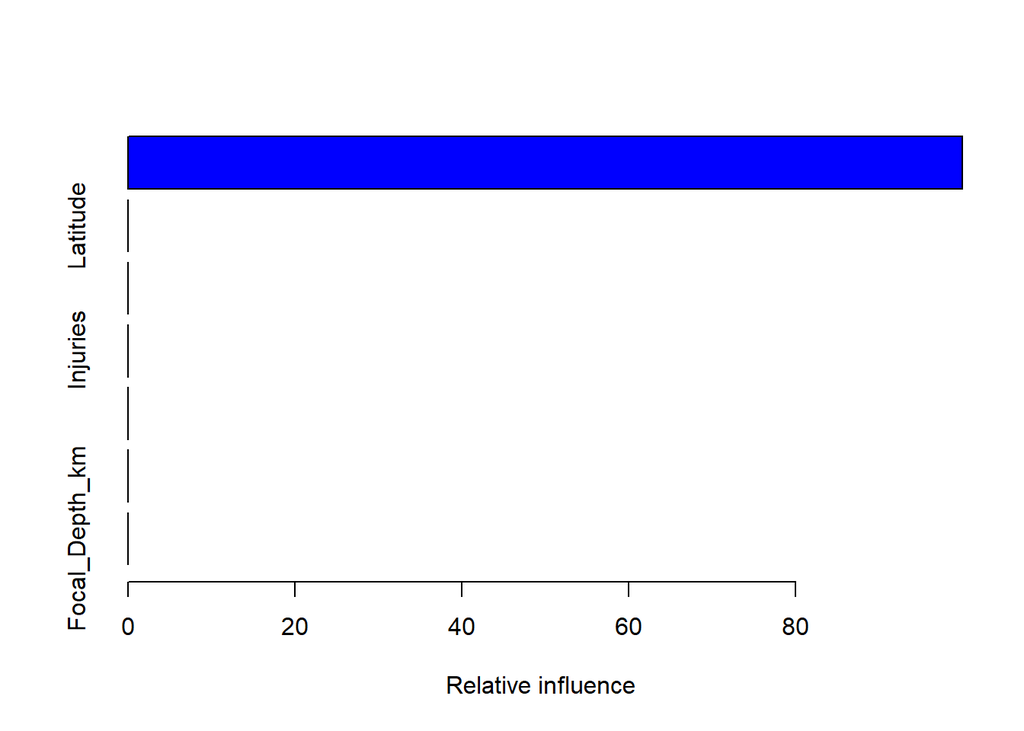

```
##                           var      rel.inf
## Mag                       Mag 9.999915e+01
## Latitude             Latitude 2.788117e-04
## Deaths                 Deaths 2.726927e-04
## Injuries             Injuries 2.283747e-04
## Longitude           Longitude 6.540567e-05
## Year                     Year 0.000000e+00
## Focal_Depth_km Focal_Depth_km 0.000000e+00
```

```r
rfdepth <- table(prediction_eq_2_rf, df_2test$Depth_class)
rfdepth_acc <- (14+136)/nrow(df_2test)

#boosting for magnitude class
set.seed(123)
library(gbm)
model_gbm = gbm(Mag_class~Year+Latitude+Longitude+Mag+Focal_Depth_km+Deaths+Injuries,data = df_2train,distribution = "multinomial",cv.folds = 10,shrinkage = .01,n.minobsinnode = 10,n.trees = 500) # 500 tress to be built #build boosting model with default values
summary(model_gbm) #summarize model inferences
```

```r
pred_test = predict.gbm(object = model_gbm,newdata = df_2test,n.trees = 500,   type = "response")# 500 tress to be built #predict classes
head(pred_test)
```

```
## , , 500
##
##             Great        Light      Major     Moderate       Strong
## [1,] 0.0033190677 1.077331e-04 0.98962814 5.599144e-04 0.0063851475
## [2,] 0.0001489481 1.072485e-04 0.99282998 5.573959e-04 0.0063564263
## [3,] 0.9791859610 1.281125e-05 0.01997534 6.658312e-05 0.0007593000
## [4,] 0.9779108560 1.359609e-05 0.02119907 7.066212e-05 0.0008058161
## [5,] 0.9779108560 1.359609e-05 0.02119907 7.066212e-05 0.0008058161
## [6,] 0.9779108560 1.359609e-05 0.02119907 7.066212e-05 0.0008058161
```

```r
labels = colnames(pred_test)[apply(pred_test, 1, which.max)] #compare predictions with actual data
result = data.frame(df_2test$Mag_class, labels)
head(result)
```

```
##   df_2test.Mag_class labels
## 1              Major  Major
## 2              Major  Major
## 3              Great  Great
## 4              Great  Great
## 5              Great  Great
## 6              Great  Great
```

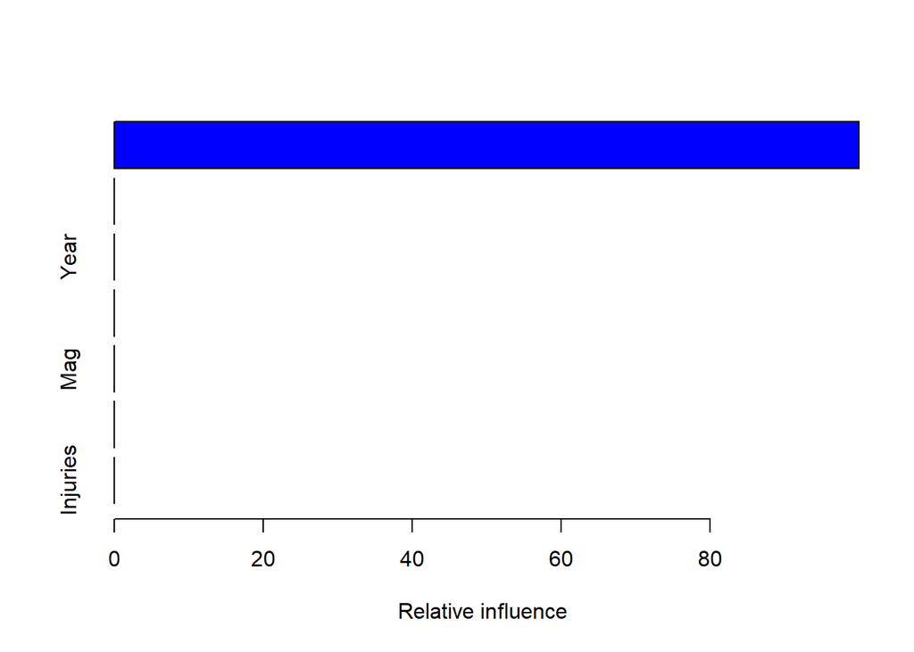

```
##                           var      rel.inf
## Focal_Depth_km Focal_Depth_km 1.000000e+02
## Longitude           Longitude 1.974834e-07
## Year                     Year 0.000000e+00
## Latitude             Latitude 0.000000e+00
## Mag                       Mag 0.000000e+00
## Deaths                 Deaths 0.000000e+00
## Injuries             Injuries 0.000000e+00
```

```r
library(caret)
cm = confusionMatrix(df_2test$Mag_class, as.factor(labels)) #compute confusion matrix


#boosting for depth class
set.seed(123)
library(gbm)
model_gbm_2 = gbm(Depth_class~Year+Latitude+Longitude+Mag+Focal_Depth_km+Deaths+Injuries,data = df_2train,distribution = "multinomial",cv.folds = 10,shrinkage = .01,n.minobsinnode = 10,n.trees = 500) # 500 tress to be built
summary(model_gbm_2)
```

```r
pred_test_2 = predict.gbm(object = model_gbm_2,newdata = df_2test,n.trees = 500,   type = "response")# 500 tress to be built
head(pred_test_2)
```

```
## , , 500
##
##      Intermediate   Shallow
## [1,] 2.253552e-05 0.9999775
## [2,] 2.253552e-05 0.9999775
## [3,] 2.253552e-05 0.9999775
## [4,] 2.253552e-05 0.9999775
## [5,] 2.253552e-05 0.9999775
## [6,] 2.253552e-05 0.9999775
```

```r
labels = colnames(pred_test_2)[apply(pred_test_2, 1, which.max)]
result = data.frame(df_2test$Depth_class, labels)
head(result)
```

```
##   df_2test.Depth_class  labels
## 1              Shallow Shallow
## 2              Shallow Shallow
## 3              Shallow Shallow
## 4              Shallow Shallow
## 5              Shallow Shallow
## 6              Shallow Shallow
```

```r
library(caret)
cm_2 = confusionMatrix(df_2test$Depth_class, as.factor(labels))
print(cm_2)
```

```
## Confusion Matrix and Statistics
##
##               Reference
## Prediction     Intermediate Shallow
##   Intermediate           14       0
##   Shallow                 0     136
##
##                Accuracy : 1
##                  95% CI : (0.9757, 1)
##     No Information Rate : 0.9067
##     P-Value [Acc > NIR] : 4.141e-07
##
##                   Kappa : 1
##
##  Mcnemar's Test P-Value : NA
##
##             Sensitivity : 1.00000
##             Specificity : 1.00000
##          Pos Pred Value : 1.00000
##          Neg Pred Value : 1.00000
##              Prevalence : 0.09333
##          Detection Rate : 0.09333
##    Detection Prevalence : 0.09333
##       Balanced Accuracy : 1.00000
##
##        'Positive' Class : Intermediate
##
```

```r
#decision tree for depth class
library(rpart)
library(rpart.plot)
library(RColorBrewer)
library(rattle)
dtree <- rpart(Depth_class~Year+Latitude+Longitude+Mag+Focal_Depth_km+Deaths+Injuries,data=df_2train,method="class",
               control = rpart.control(minsplit=20,minbucket = 7,maxdepth = 10,usesurrogate = 2,xval = 10)) #formulate decision tree using default values
dtree #print tree information
```

```
## n= 671
##
## node), split, n, loss, yval, (yprob)
##       * denotes terminal node
##
## 1) root 671 40 Shallow (0.05961252 0.94038748)
##   2) Focal_Depth_km>=71.5 40  0 Intermediate (1.00000000 0.00000000) *
##   3) Focal_Depth_km< 71.5 631  0 Shallow (0.00000000 1.00000000) *
```

```r
#decision tree for mag class
library(rpart)
library(rpart.plot)
library(RColorBrewer)
library(rattle)
dtree_2 <- rpart(Mag_class~Year+Latitude+Longitude+Mag+Focal_Depth_km+Deaths+Injuries,data=df_2train,method="class",
               control = rpart.control(minsplit=20,minbucket = 7,maxdepth = 10,usesurrogate = 2,xval = 10))
dtree_2
```

```
## n= 671
##
## node), split, n, loss, yval, (yprob)
##       * denotes terminal node
##
##  1) root 671 407 Strong (0.028 0.083 0.18 0.31 0.39)
##    2) Mag< 5.95 267  56 Moderate (0 0.21 0 0.79 0)
##      4) Mag< 4.95 56   0 Light (0 1 0 0 0) *
##      5) Mag>=4.95 211   0 Moderate (0 0 0 1 0) *
##    3) Mag>=5.95 404 140 Strong (0.047 0 0.3 0 0.65)
##      6) Mag>=6.95 140  19 Major (0.14 0 0.86 0 0)
##       12) Mag>=7.95 19   0 Great (1 0 0 0 0) *
##       13) Mag< 7.95 121   0 Major (0 0 1 0 0) *
##      7) Mag< 6.95 264   0 Strong (0 0 0 0 1) *
```

## Risk Raster Map (Time Series Forecasting)

### We have used the ARIMA (Autoregressive Integrated Moving Average) function for forecasting the coordinates of epicenters of future occurrences and visualized the same on raster maps.

### We created a time series for the latitude and longitude using the starting date, ending date and frequency as parameters.

### Based on the time series created, we used the ARIMA function for forecasting the coordinates.

### The resulting coordinates were visualized on risk raster maps to highlight disaster prone zones.

```r
#raster map (forecasting disaster-prone zone)
#latitude
data_eu <- read.csv("C:/Users/Muthug/Desktop/INFO521 Intro to ML/fpquake_eu.csv") #read tectonic plate data
library(forecast)
set.seed(123)
latitude_ts <- ts(data_eu$Latitude,start=c(1880,7),end=c(2022,9),frequency = 12) #create time series for latitude
latitude_fit <- auto.arima(latitude_ts) #fit values using time series
latitude_fc <- forecast(latitude_fit,25) #forecast the coordinates
latitude_summ <- summary(latitude_fc) #summarize forecasts
```

```
##
## Forecast method: ARIMA(1,0,0) with non-zero mean
##
## Model Information:
## Series: latitude_ts
## ARIMA(1,0,0) with non-zero mean
##
## Coefficients:
##          ar1    mean
##       0.9686  31.766
## s.e.  0.0060   1.524
##
## sigma^2 estimated as 4.056:  log likelihood=-3617.69
## AIC=7241.38   AICc=7241.39   BIC=7257.71
##
## Error measures:
##                      ME     RMSE       MAE       MPE     MAPE      MASE
## Training set 0.01590664 2.012891 0.3578566 -0.545675 1.518729 0.1491734
##                      ACF1
## Training set -0.003932581
##
## Forecasts:
##          Point Forecast    Lo 80    Hi 80    Lo 95    Hi 95
## Oct 2022       36.45785 33.87671 39.03898 32.51034 40.40535
## Nov 2022       36.31047 32.71707 39.90388 30.81483 41.80611
## Dec 2022       36.16773 31.83456 40.50090 29.54071 42.79474
## Jan 2023       36.02947 31.10224 40.95670 28.49392 43.56502
## Feb 2023       35.89555 30.46981 41.32129 27.59760 44.19350
## Mar 2023       35.76584 29.91088 41.62080 26.81145 44.72023
## Apr 2023       35.64020 29.40938 41.87102 26.11099 45.16941
## May 2023       35.51851 28.95462 42.08240 25.47990 45.55712
## Jun 2023       35.40064 28.53895 42.26233 24.90659 45.89469
## Jul 2023       35.28648 28.15670 42.41625 24.38242 46.19053
## Aug 2023       35.17590 27.80347 42.54832 23.90074 46.45105
## Sep 2023       35.06879 27.47576 42.66181 23.45626 46.68132
## Oct 2023       34.96505 27.17074 42.75935 23.04468 46.88541
## Nov 2023       34.86456 26.88603 42.84309 22.66246 47.06667
## Dec 2023       34.76724 26.61966 42.91481 22.30660 47.22787
## Jan 2024       34.67297 26.36993 42.97600 21.97457 47.37136
## Feb 2024       34.58166 26.13537 43.02794 21.66418 47.49913
## Mar 2024       34.49322 25.91471 43.07172 21.37353 47.61290
## Apr 2024       34.40755 25.70684 43.10827 21.10096 47.71415
## May 2024       34.32458 25.51075 43.13841 20.84499 47.80417
## Jun 2024       34.24421 25.32557 43.16286 20.60432 47.88411
## Jul 2024       34.16637 25.15050 43.18225 20.37778 47.95497
## Aug 2024       34.09098 24.98483 43.19713 20.16432 48.01763
## Sep 2024       34.01795 24.82791 43.20798 19.96300 48.07289
## Oct 2024       33.94721 24.67917 43.21526 19.77297 48.12146
```

```r
#longitude
library(forecast)
set.seed(123)
longitude_ts <- ts(data_eu$Longitude,start=c(1880,7),end=c(2022,9),frequency = 12)
longitude_fit <- auto.arima(longitude_ts)
longitude_fc <- forecast(longitude_fit,25)
longitude_summ <- summary(longitude_fc)
```

```
##
## Forecast method: ARIMA(5,0,3)(1,0,2)[12] with non-zero mean
##
## Model Information:
## Series: longitude_ts
## ARIMA(5,0,3)(1,0,2)[12] with non-zero mean
##
## Coefficients:
##          ar1     ar2     ar3      ar4     ar5      ma1      ma2      ma3
##       0.3341  0.1437  0.3913  -0.1055  0.1776  -0.1134  -0.0961  -0.1973
## s.e.  0.1859  0.1491  0.1060   0.0375  0.0512   0.1874   0.1231   0.1002
##          sar1    sma1     sma2     mean
##       -0.6937  0.6817  -0.0723  72.7887
## s.e.   0.0874  0.0882   0.0251   6.3754
##
## sigma^2 estimated as 790.9:  log likelihood=-8112.53
## AIC=16251.05   AICc=16251.27   BIC=16321.81
##
## Error measures:
##                       ME     RMSE     MAE    MPE     MAPE      MASE        ACF1
## Training set -0.03693963 28.02434 20.2845 177.23 352.9175 0.6979411 0.001004035
##
## Forecasts:
##          Point Forecast    Lo 80    Hi 80      Lo 95    Hi 95
## Oct 2022       66.34512 30.30357 102.3867 11.2243265 121.4659
## Nov 2022       66.94595 30.03651 103.8554 10.4978385 123.3941
## Dec 2022       69.07166 31.90376 106.2396 12.2282628 125.9151
## Jan 2023       70.95799 32.57146 109.3445 12.2508496 129.6651
## Feb 2023       67.25467 28.73929 105.7700  8.3504817 126.1589
## Mar 2023       68.60649 28.88768 108.3253  7.8618106 129.3512
## Apr 2023       65.02653 24.42913 105.6239  2.9381590 127.1149
## May 2023       67.56948 26.64067 108.4983  4.9742578 130.1647
## Jun 2023       68.90716 27.18210 110.6322  5.0941852 132.7201
## Jul 2023       65.46859 23.27355 107.6636  0.9368415 130.0003
## Aug 2023       73.28938 30.65065 115.9281  8.0790689 138.4997
## Sep 2023       71.45665 28.23572 114.6776  5.3559495 137.5573
## Oct 2023       69.89223 26.34327 113.4412  3.2898379 136.4946
## Nov 2023       69.94156 25.97758 113.9055  2.7044481 137.1787
## Dec 2023       67.98514 23.60593 112.3643  0.1129927 135.8573
## Jan 2024       65.57399 20.86664 110.2813 -2.7999926 133.9480
## Feb 2024       69.68978 24.61702 114.7625  0.7569379 138.6226
## Mar 2024       68.81480 23.42298 114.2066 -0.6059915 138.2356
## Apr 2024       72.28378 26.59904 117.9685  2.4150022 142.1526
## May 2024       69.97199 23.98723 115.9568 -0.3556351 140.2996
## Jun 2024       69.81906 23.56836 116.0698 -0.9152827 140.5534
## Jul 2024       72.31085 25.80341 118.8183  1.1838555 143.4378
## Aug 2024       66.58515 19.83030 113.3400 -4.9202240 138.0905
## Sep 2024       68.53147 21.55006 115.5129 -3.3203964 140.3833
## Oct 2024       69.45189 22.41695 116.4868 -2.4818431 141.3856
```

```r
#visualizing disaster prone areas using map
#actual data points
wmap_fc_1 <- borders("world",colour = "gray50",fill="gray50")
eqmap_fc_1<- ggplot() + wmap_fc_1
eqmap_fc_1 <- eqmap_fc_1 + geom_point(data=data_eu,aes(x=as.numeric(Longitude),y=as.numeric(Latitude),color=Mag)) +ggtitle("EU Plate Epicenters of Earthquakes on World Map")+
  xlab("Longitude") + ylab("Latitude")
myPalette_fc_1 <- colorRampPalette(rev(brewer.pal(11,"Spectral")))
sc1_fc_1 <- scale_colour_gradientn(colours = myPalette_fc_1(100))
raster_1 <- eqmap_fc_1 + sc1_fc_1

#predicted points using arima
library(ggshadow)
data_eu_predict <- data_eu <- read.csv("C:/Users/Muthug/Desktop/INFO521 Intro to ML/fpquake_eu_predict.csv")

wmap_fc_2 <- borders("world",colour = "gray50",fill="gray50")
eqmap_fc_2<- ggplot() + wmap_fc_2
eqmap_fc_2 <- eqmap_fc_2 + geom_glowpoint(data=data_eu_predict,aes(x=as.numeric(Longitude),y=as.numeric(Latitude)),color = "#6bb857",alpha=0.8,shadowcolor="#6bb857",shadowalpha=0.1) +ggtitle("Predicted Epicenters On Eurasian (EU) Plate")+
  xlab("Longitude") + ylab("Latitude") + theme_void()
raster_2 <- eqmap_fc_2
```

# Results

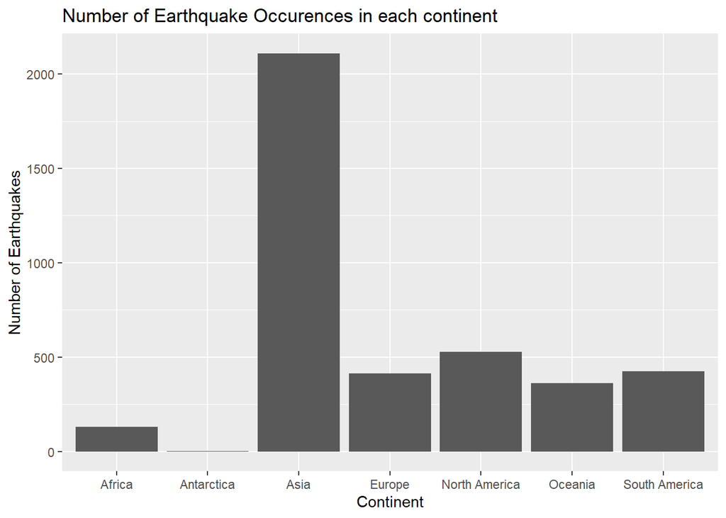

```r
bp_1
```

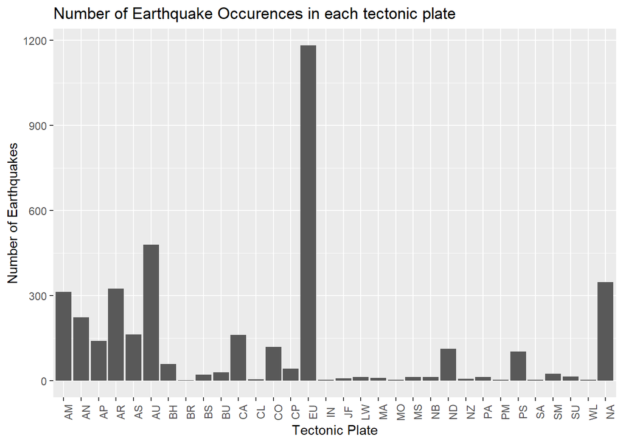

```r
bp_2
```

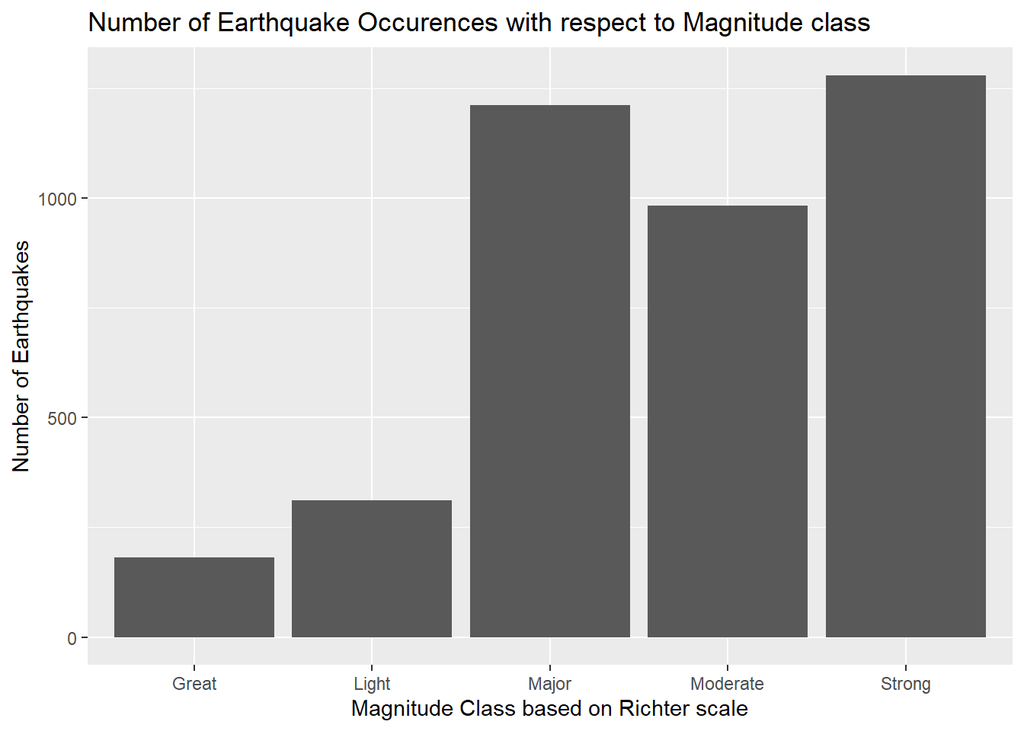

```r
bp_3
```

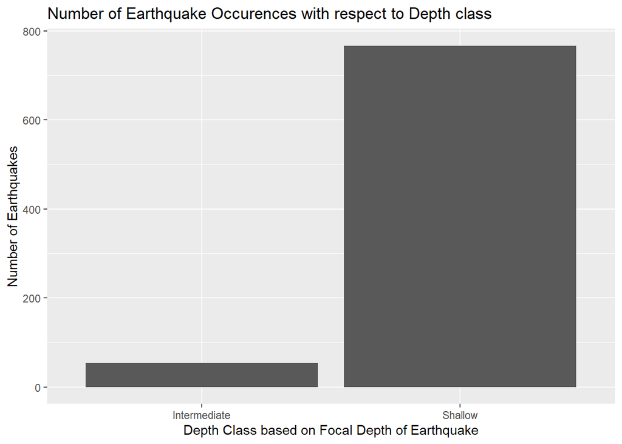

```r
bp_4
```

### From the visuals above, it is evident that most number of earthquakes have taken place in Asia and the Eurasian plate.

### From the visuals above, it can be observed that most earthquakes are strong i.e. Magnitude between 6 and 7.

### Most earthquakes were shallow in depth i.e. Focal depth between 0 and 70 km.

```r
lp_1
```

```
## geom_path: Each group consists of only one observation. Do you need to adjust
## the group aesthetic?
```

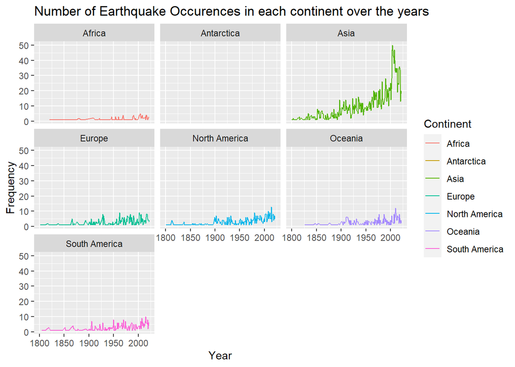

```r
lp_2
```

```
## geom_path: Each group consists of only one observation. Do you need to adjust
## the group aesthetic?
```

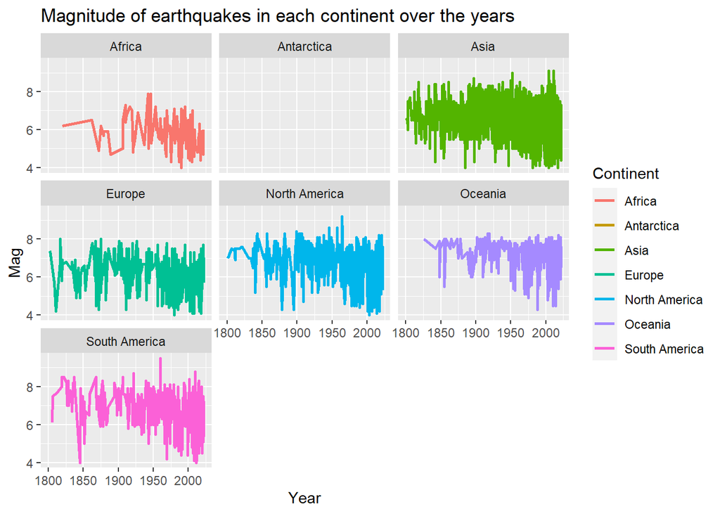

### From the visuals above, it is evident that in every continent except Antarctica, there has been an increase in earthquake occurrences over the years and its magnitudes have been random over a period of time.

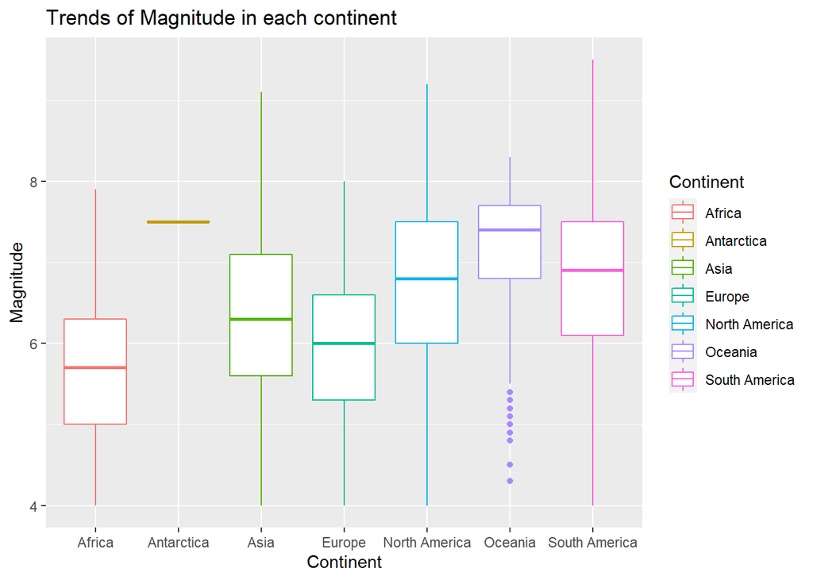

```r
box_1
```

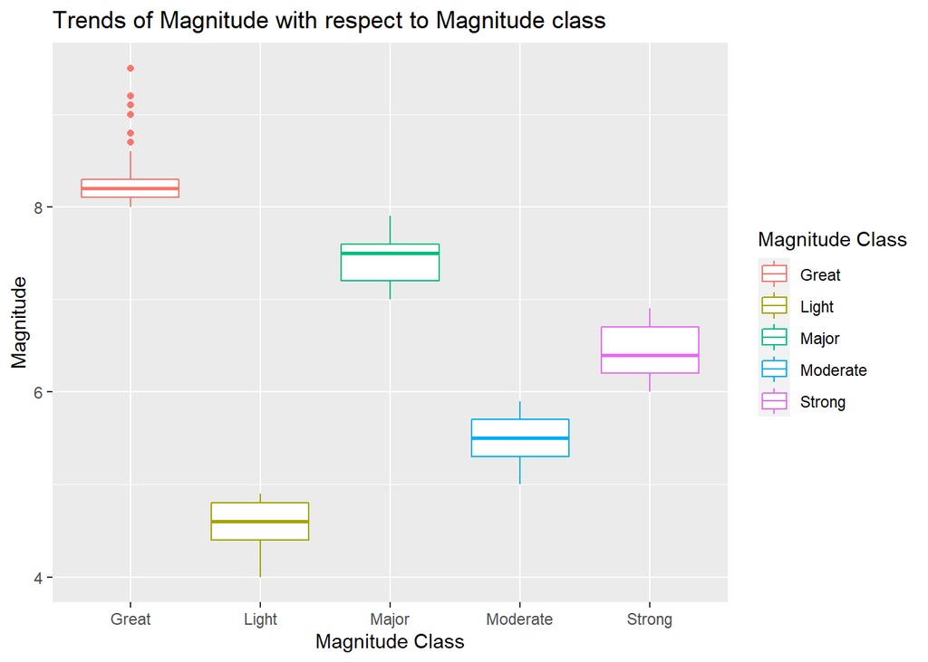

```r
box_2
```

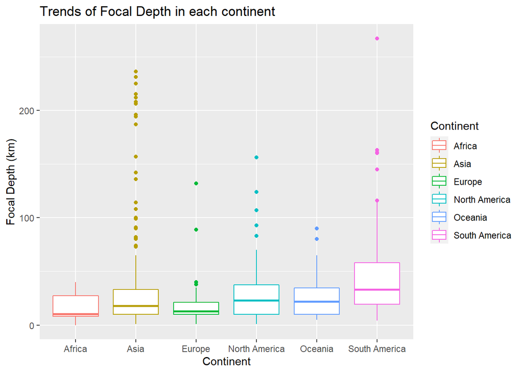

```r
box_3
```

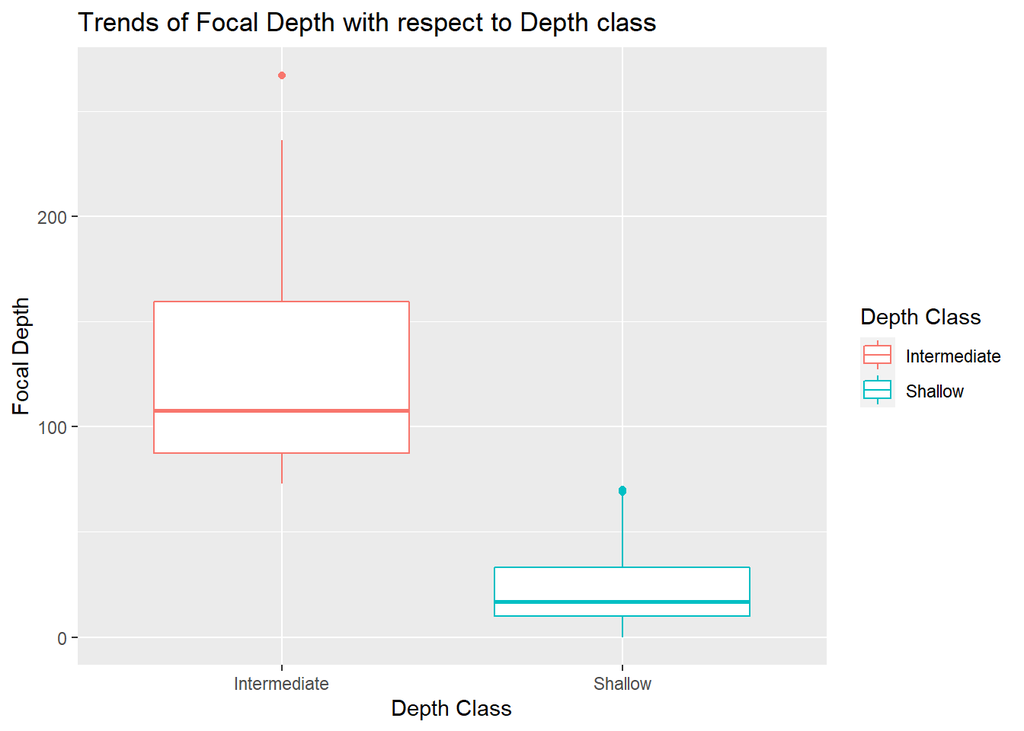

```r
box_4
```

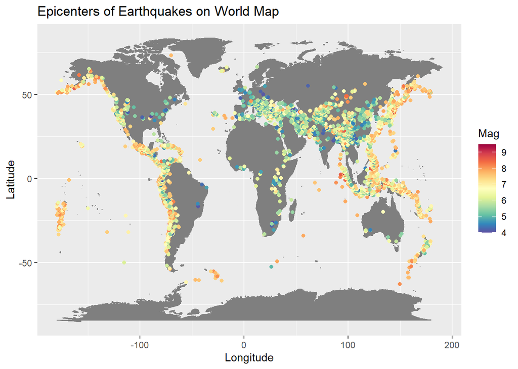

```r
map_1
```

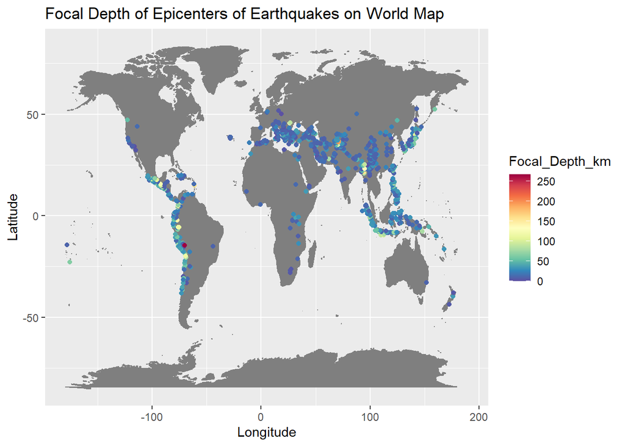

```r
map_2
```

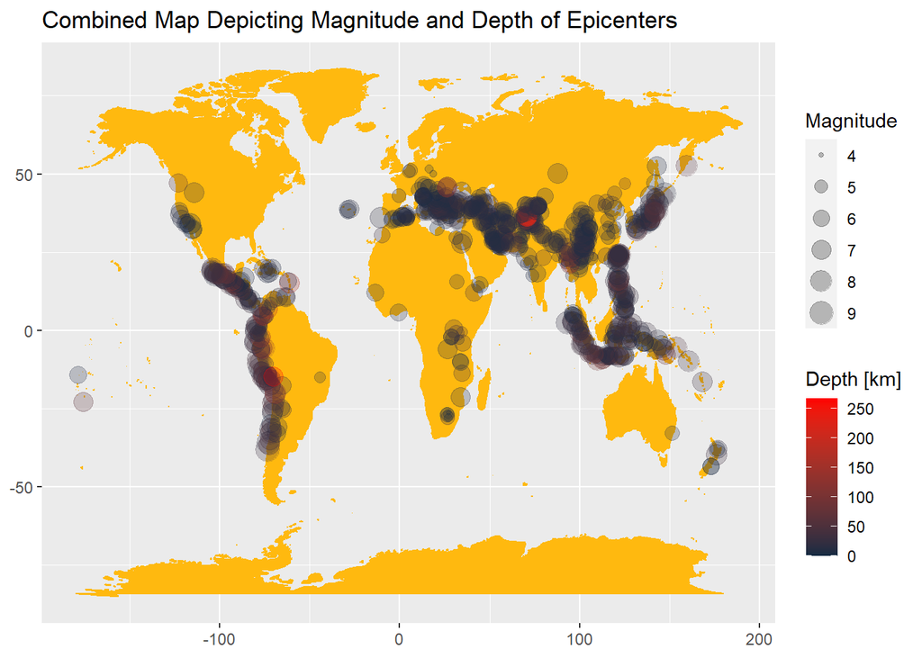

```r
magdepmap
```

### From the visuals above, the magnitudes of the earthquakes in the coastal areas and island nations is very high when compared with other areas. The focal depths of earthquakes in the coastal areas is very low.

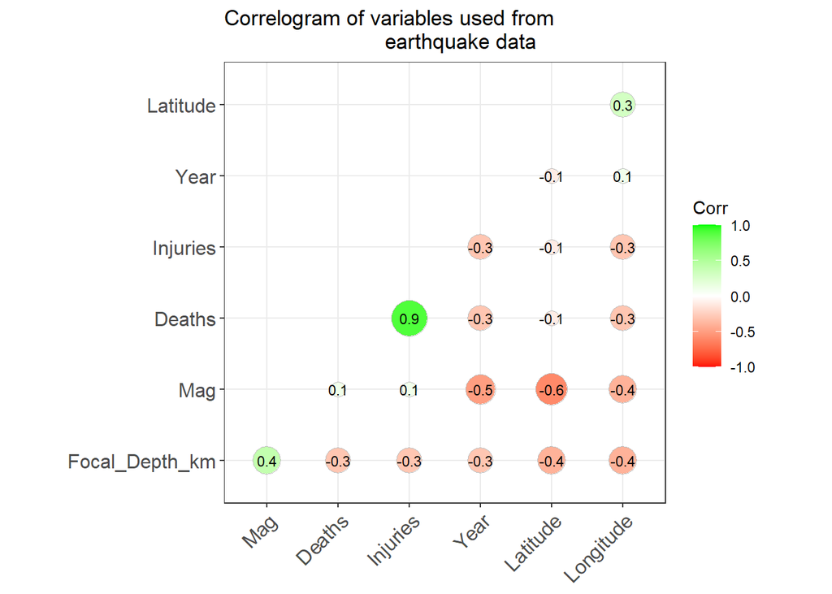

```r
corr_eqplot
```

### Green color depicts positive correlation, Red color depicts negative correlation and white color depicts neutral correlation. From the visuals above, it is clearly understood that there exists a strong positive correlation between Deaths and Injuries and there exists a strong negative correlation between Magnitude and Latitude. Due to the presence of missing values and the dataset being retrieved from government sources, the dataset as such has a negative correlation overall.

## Aggregate Functions for Statistic Details

### Country with highest average magnitude

```r
eq_mean = aggregate(df_2[,6],by=list(df_2$Country),FUN=mean, na.rm=TRUE)
eq_mean
```

```
##               Group.1        x
## 1         Afghanistan 6.085714
## 2             Albania 5.975000
## 3             Algeria 5.560000
## 4           Argentina 6.600000
## 5           Australia 5.400000
## 6          Azerbaijan 6.100000
## 7          Bangladesh 5.233333
## 8             Belgium 5.100000
## 9             Bolivia 6.600000
## 10             Brazil 4.600000
## 11           Bulgaria 6.200000
## 12              Chile 7.644444
## 13              China 5.860638
## 14           Colombia 6.353846
```

[output cut: 69 more lines]

```r
which.max(eq_mean$x) #Solomon Islands is 67th in the list ; 8.1 mag
```

```
## [1] 67
```

### Tectonic plate with highest average magnitude

```r
eq_mean_2 = aggregate(df_2[,6],by=list(df_2$Tectonic_Plate),FUN=mean, na.rm=TRUE)
eq_mean_2
```

```
##    Group.1        x
## 1       AM 6.501818
## 2       AN 7.222222
## 3       AP 6.459459
## 4       AR 5.939806
## 5       AS 6.118750
## 6       AU 6.709459
## 7       BH 6.773333
## 8       BS 6.525000
## 9       BU 6.785714
## 10      CA 6.391176
## 11      CO 6.970000
## 12      CP 6.536364
## 13      EU 6.036877
## 14      IN 6.800000
## 15      LW 5.162500
## 16      MS 7.000000
## 17      NB 7.600000
## 18      ND 6.284615
## 19      NZ 7.500000
## 20      PA 6.400000
## 21      PS 6.580000
## 22      SA 6.200000
## 23      SM 5.512500
## 24      SU 6.600000
```

```r
which.max(eq_mean_2$x) #NB Tectonic Plate is 17th in the list ; 7.6 mag
```

```
## [1] 17
```

### Country with highest loss of lives

```r
eq_sum = aggregate(df_2[,7],by=list(df_2$Country),FUN=sum, na.rm=TRUE)
eq_sum
```

```
##               Group.1      x
## 1         Afghanistan   6732
## 2             Albania    130
## 3             Algeria   8669
## 4           Argentina     80
## 5           Australia     12
## 6          Azerbaijan    119
## 7          Bangladesh     10
## 8             Belgium      3
## 9             Bolivia    105
## 10             Brazil      1
## 11           Bulgaria    130
## 12              Chile   2724
## 13              China 378810
## 14           Colombia   2476
```

[output cut: 69 more lines]

```r
which.max(eq_sum$x) #China is 13th in the list ; 378810 lives lost
```

```
## [1] 13
```

### Tectonic plate with highest loss of lives

```r
eq_sum_2 = aggregate(df_2[,7],by=list(df_2$Tectonic_Plate),FUN=sum, na.rm=TRUE)
eq_sum_2
```

```
##    Group.1      x
## 1       AM 404851
## 2       AN   3234
## 3       AP  25467
## 4       AR 155195
## 5       AS   1748
## 6       AU  77299
## 7       BH    204
## 8       BS   4692
## 9       BU    170
## 10      CA 354229
## 11      CO  10364
## 12      CP   2617
## 13      EU 312087
## 14      IN      1
## 15      LW     47
## 16      MS     11
## 17      NB      4
## 18      ND   3198
## 19      NZ     88
## 20      PA     22
## 21      PS   1549
## 22      SA    443
## 23      SM    225
## 24      SU     10
```

```r
which.max(eq_sum_2$x) #AM Tectonic Plate is 1st in the list ; 404851 lives lost
```

```
## [1] 1
```

### It can be said that Asian and Eurasian plate earthquakes were of lesser intensity.

# Discussion

## Multiple Linear Regression

### Initially, a linear model was built to predict the magnitude of an earthquake based on all quantitative variables in the dataset. The predictor variables which are important for finding the best fit line to predict the magnitude of an earthquake were identified such as Focal depth, Latitude, Injuries etc. based on the p value of the variables in the dataset.

### Once, the predictor variables were identified the linear model was rebuilt using these variables as predictor variables against the magnitude of an earthquake as response variable.

### The p value of the predictor variables used in the second model are observed to be low (lesser than 0) indicating there is significant relationship between the response variable and predictor variables.

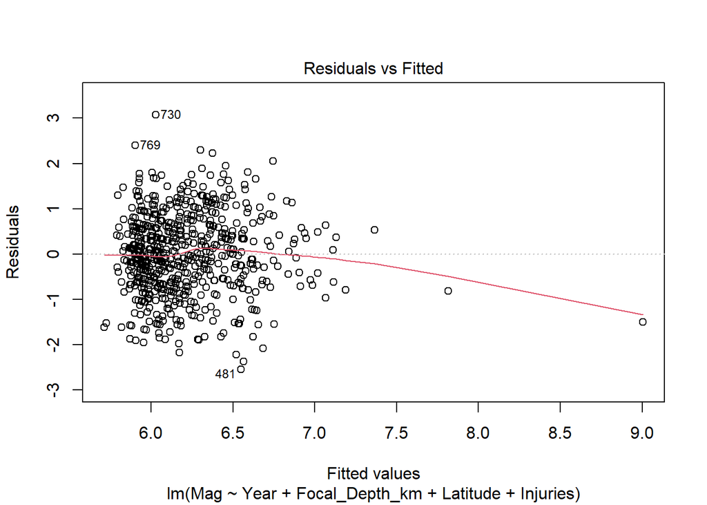

```r
plot(model2_train,1)
```

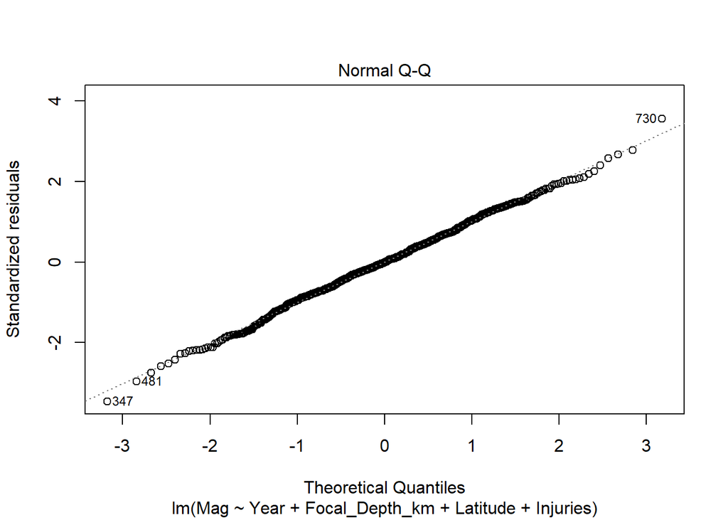

```r
plot(model2_train,2)
```

### The Residuals vs Fitted Plot of the model gives almost a horizontal red line without distinct patterns indicating a linear relationship between predictor variables and the response variable in the model.

### The Normal Q-Q Plot of the model almost follow a straight dashed line indicating that the residual errors in the model are normally distributed.

```r
summary(pred_2)
```

```
##    Min. 1st Qu.  Median    Mean 3rd Qu.    Max.
##   5.949   6.112   6.221   6.332   6.483   7.369
```

```r
summary(df_2test$Mag)
```

```
##    Min. 1st Qu.  Median    Mean 3rd Qu.    Max.
##   4.300   6.100   6.700   6.689   7.375   9.500
```

### Upon deriving the summary for our predicted magnitudes and when we compare it with the actual magnitudes being recorded, the 1st Quartile values differed by a small margin of 0.012. The average magnitude for the predicted and actual values differed by 0.357.

## Logistic Regression for Depth Class

```r
cmlogreg #confusion matrix for model
```

```
##               predict_logreg_values
##                Intermediate Shallow
##   Intermediate           14       0
##   Shallow                 1     135
```

```r
cmlogreg_acc #accuracy of model
```

```
## [1] 0.9933333
```

## Random Forest for Magnitude Class

```r
rfmag #confusion matrix for model
```

```
##
## prediction_eq_rf Great Light Major Moderate Strong
##         Great        8     0     0        0      0
##         Light        0     5     0        0      0
##         Major        3     0    53        0      0
##         Moderate     0     0     0       24      0
##         Strong       0     0     0        0     57
```

```r
rfmag_acc #accuracy of model
```

```
## [1] 0.98
```

## Random Forest for Depth Class

```r
rfdepth #confusion matrix for model
```

```
##
## prediction_eq_2_rf Intermediate Shallow
##       Intermediate           14       0
##       Shallow                 0     136
```

```r
rfdepth_acc #accuracy of model
```

```
## [1] 1
```

## Boosting for Magnitude Class

```r
print(cm) #confusion matrix for model
```

```
## Confusion Matrix and Statistics
##
##           Reference
## Prediction Great Light Major Moderate Strong
##   Great       11     0     0        0      0
##   Light        0     5     0        0      0
##   Major        0     0    53        0      0
##   Moderate     0     0     0       24      0
##   Strong       0     0     0        0     57
##
## Overall Statistics
##
##                Accuracy : 1
##                  95% CI : (0.9757, 1)
##     No Information Rate : 0.38
##     P-Value [Acc > NIR] : < 2.2e-16
##
##                   Kappa : 1
##
##  Mcnemar's Test P-Value : NA
##
## Statistics by Class:
##
##                      Class: Great Class: Light Class: Major Class: Moderate
## Sensitivity               1.00000      1.00000       1.0000            1.00
## Specificity               1.00000      1.00000       1.0000            1.00
## Pos Pred Value            1.00000      1.00000       1.0000            1.00
## Neg Pred Value            1.00000      1.00000       1.0000            1.00
## Prevalence                0.07333      0.03333       0.3533            0.16
## Detection Rate            0.07333      0.03333       0.3533            0.16
## Detection Prevalence      0.07333      0.03333       0.3533            0.16
## Balanced Accuracy         1.00000      1.00000       1.0000            1.00
##                      Class: Strong
## Sensitivity                   1.00
## Specificity                   1.00
## Pos Pred Value                1.00
## Neg Pred Value                1.00
## Prevalence                    0.38
## Detection Rate                0.38
## Detection Prevalence          0.38
## Balanced Accuracy             1.00
```

## Boosting for Depth Class

```r
print(cm_2) #confusion matrix for model
```

```
## Confusion Matrix and Statistics
##
##               Reference
## Prediction     Intermediate Shallow
##   Intermediate           14       0
##   Shallow                 0     136
##
##                Accuracy : 1
##                  95% CI : (0.9757, 1)
##     No Information Rate : 0.9067
##     P-Value [Acc > NIR] : 4.141e-07
##
##                   Kappa : 1
##
##  Mcnemar's Test P-Value : NA
##
##             Sensitivity : 1.00000
##             Specificity : 1.00000
##          Pos Pred Value : 1.00000
##          Neg Pred Value : 1.00000
##              Prevalence : 0.09333
##          Detection Rate : 0.09333
##    Detection Prevalence : 0.09333
##       Balanced Accuracy : 1.00000
##
##        'Positive' Class : Intermediate
##
```

# Summary of Model Accuracy

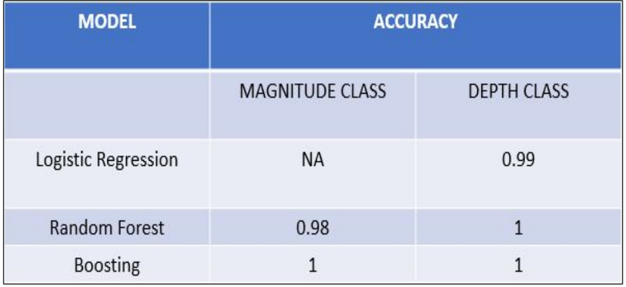

## We have classified the earthquake in terms of its magnitude scale and its focal depth. We used machine learning algorithms like random forest and logistic regression for doing so. We also introduced boosting since it is a very powerful algorithm, providing better accuracies when compared with the other models being implemented.

## We had compared our Random forest model with [1] Asim, Basit et al. their model had obtained an accuracy of 62%, where as our models achieved full accuracy for classifying depth-class and 98% accuracy for classifying magnitude-class.

## Decision Tree for Depth Class

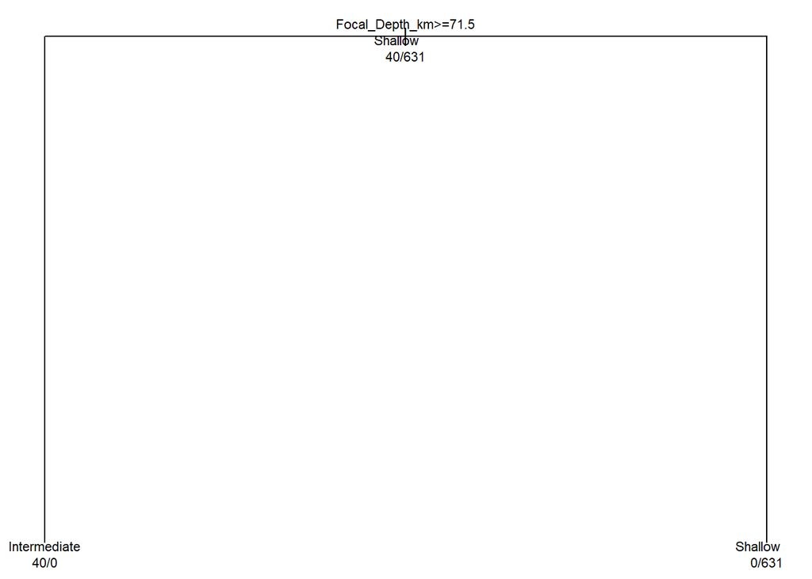

```r
#print basic and detailed decision trees
par(xpd=NA,mar=rep(0.7,4))
plot(dtree,compress = TRUE)
text(dtree,cex=0.7,use.n = TRUE,fancy=FALSE,all=TRUE)
```

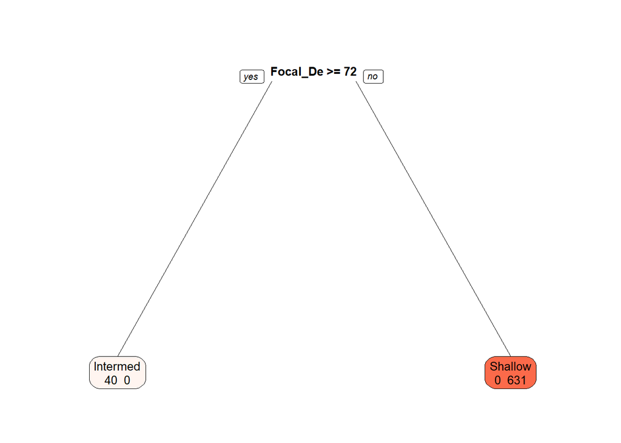

```r
library(rpart.plot)
prp(dtree,faclen=0,box.palette="Reds",cex=0.8,extra=1)
```

## Decision Tree for Magnitude Class

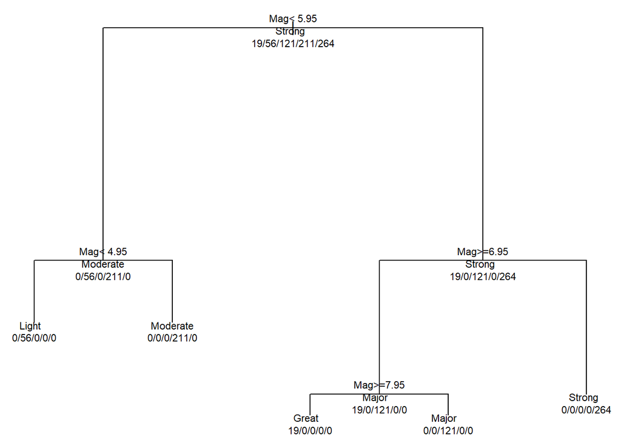

```r
#print basic and detailed decision trees
par(xpd=NA,mar=rep(0.7,4))
plot(dtree_2,compress = TRUE)
text(dtree_2,cex=0.7,use.n = TRUE,fancy=FALSE,all=TRUE)
```

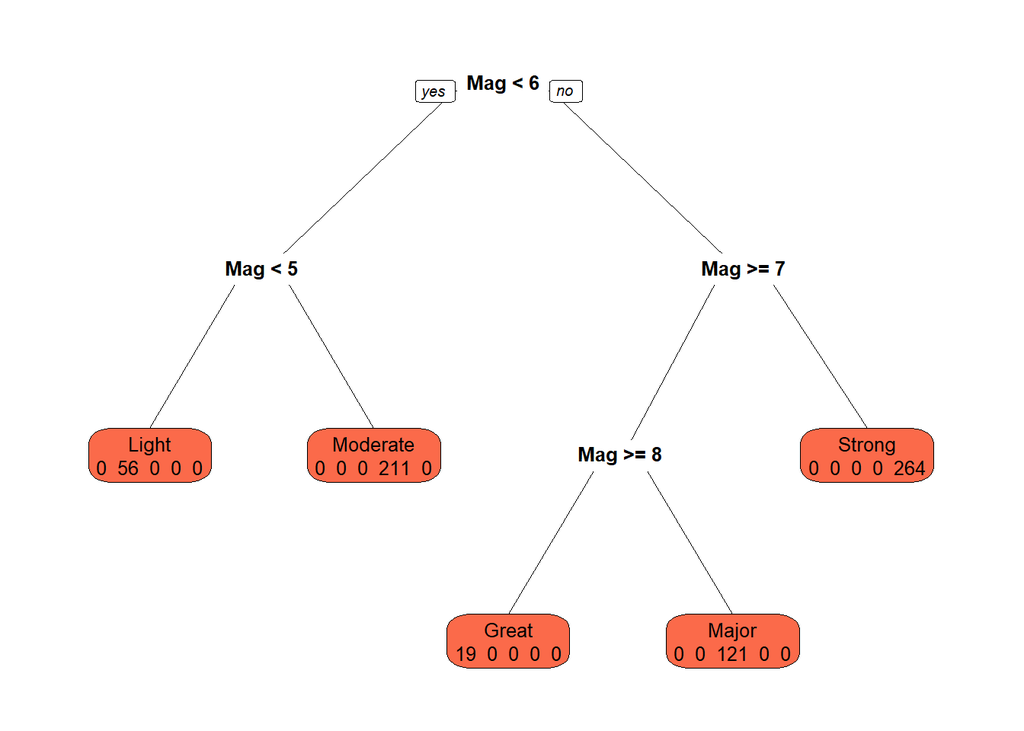

```r
library(rpart.plot)
prp(dtree_2,faclen=0,box.palette="Reds",cex=0.8,extra=1)
```

### We also constructed a decision tree in order to check whether an earthquake is of a particular magnitude scale or depth type. The trees we obtained comply with the actual definitions of those terms.

## Risk Raster Maps

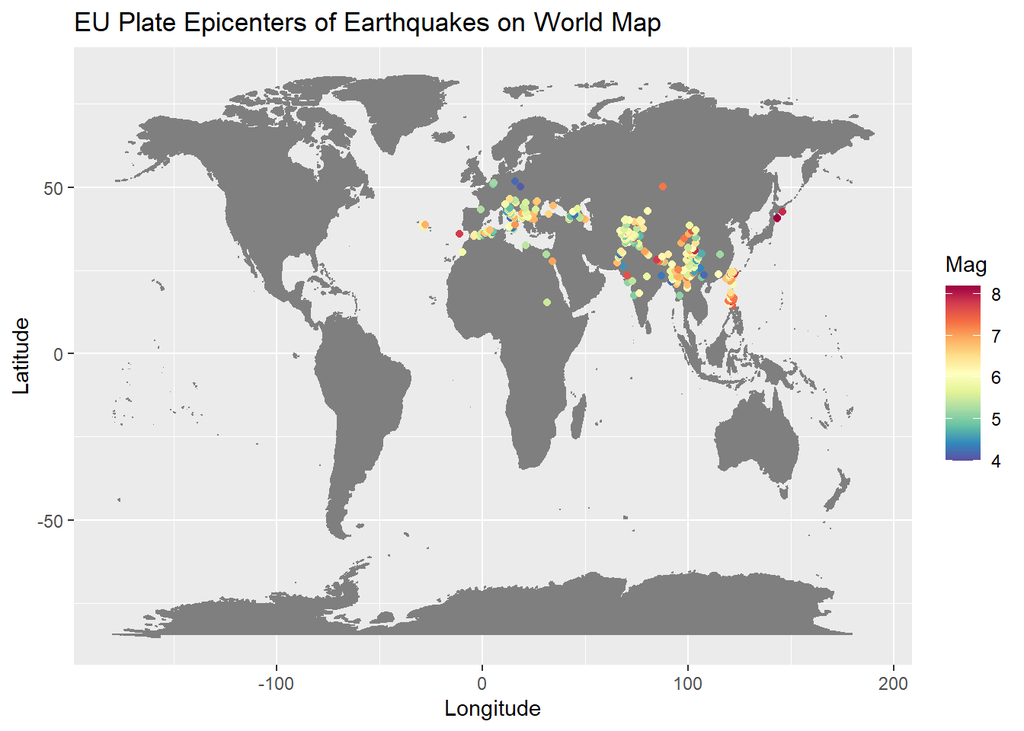

```r
raster_1
```

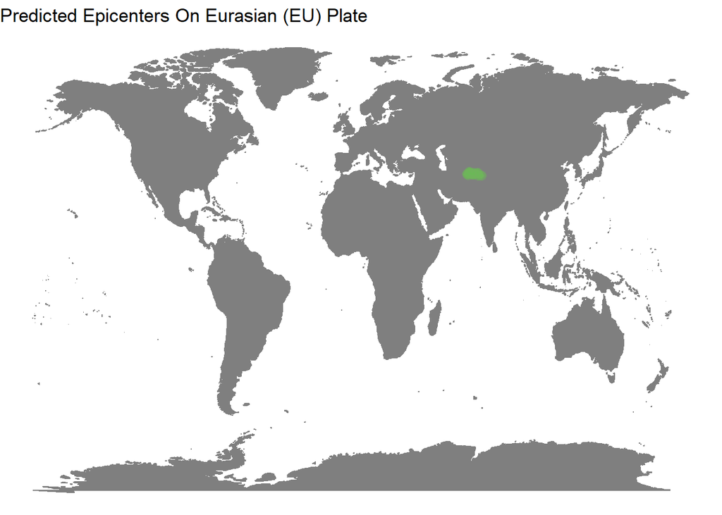

```r
raster_2
```

### Finally we computed a risk raster map which is a low quality pixel map used for visualizing our forecasted epicenter coordinates (disaster prone zones). We forecasted the epicenter coordinates for 25 instances and we were able to observe that most of it were plotted in the Afghan Hindukush mountain range which in reality is prone to earthquakes. These notable lie in Eurasian plate whose actual data was used to forecast the epicenter coordinates.

# Conclusion

## To sum up our work,

### The Eu, AM and NB plates had much impact due to earthquakes.

### Countries like Solomon Islands, China etc. had much loss of lives and intense earthquakes.

### The analysis and prediction of the earthquakes using location-based historical data is possible given a sufficient volume of data.

### The various tectonic plates and its boundaries gave a better understanding on how earthquakes sites along these boundaries will allow us to make educated estimates on the magnitudes and depths of the earthquakes.

### Each tectonic plate has its own patterns of seismic activity, which was thoroughly analyzed statistically and visually.

### All this opens up avenues in creating a foundation for the use of tectonic plate locations, their boundaries and geographical variations in the use of forecasting and predicting the periodicity of the earthquakes along with its intensity and possible epicentres.

#### We as citizens should always remain high on alert.

#### We should not panic whenever a natural disaster occurs and must not hesitate to help others in need.

#### We must always mind the crack.

#### We must be prepared, aware and ready.

# References (Paper Links)

### https://link.springer.com/article/10.1007/s11069-020-04125-2

### https://www.researchgate.net/profile/Khawaja-Asim/publication/307951466_Earthquake_magnitude_prediction_in_Hindukush_region_using_machine_learning_techniques/links/59ed755eaca272cddde0657a/Earthquake-magnitude-prediction-in-Hindukush-region-using-machine-learning-techniques.pdf

### https://www.mdpi.com/2071-1050/12/6/2420

# Thank You